# 📈 类群结构、资源状态与趋势

Source: [`vignettes/articles/zh/status-trends.Rmd`](https://github.com/Linbojun99/faofishingreport/blob/main/vignettes/articles/zh/status-trends.Rmd)

```r
fao_settings(lang = "zh")   # 本文所有图表使用中文
```

📦 **数据来源**：[FAO全球捕捞产量](https://www.fao.org/fishery/collection/capture/en)（Global Capture Production）**2026.1.0**版（FAO于2026-03-30发布，1950–2024年），下载地址Capture_2026.1.0.zip，许可证[CC BY 4.0](https://creativecommons.org/licenses/by/4.0/)。用`fao_data_info()`查看你使用的版本和引用格式。

汇总分析适用于任何产量数据：可以是`fishing_area_data()`得到的某个渔区，也可以是`load_fao_data()`的任意子集（见💾 FAO数据）。图表保存在`figures/png/summary/`，表格保存在`tables/`，文件名以渔区名称（或`label`的值）开头。每个函数还会以不可见的方式返回结果，可以赋值给变量后在R中继续使用。

```r
FAO27 <- fishing_area_data("Atlantic, Northeast")
```

## ⚙️ 通用参数

本文大多数函数都有下面这些参数，后面各函数的参数表只列出它们自己的参数。

| 参数 | 含义 | 默认值 |
| --- | --- | --- |
| `area_data` | FAO产量数据：`fishing_area_data()$area_data`，或`load_fao_data()`的任意子集（如一个国家或几个渔区） | 必填 |
| `plot` | 是否把图保存到`figures/png/summary/` | `TRUE` |
| `table` | 是否把表格保存到`tables/` | `TRUE` |
| `lang` | 图中文字和名称的语言：`"en"`、`"zh"`或`"both"` | `NULL`：使用`fao_settings()`设定的语言（未修改时为`"en"`） |
| `pptx` | 是否同时把图保存为可编辑的PowerPoint文件，存放在`figures/pptx/summary/` | `FALSE`；`fao_settings(pptx = TRUE)`可对所有函数生效 |
| `plot_show` | 保存图表的同时把图画在绘图窗口中（例如RStudio的Plots窗格） | `FALSE`，或`fao_settings()`中的`plot_show` |
| `label` | 输出文件名开头的名称 | `NULL`：数据所属的渔区（或国家；含多个渔区和国家时为`"selected_data"`） |

## 🧺 物种类群结构

`species_group_composition()`按**ISSCAAP物种类群**（FAO将物种划分为约50个类群的分类体系，如”Herrings, sardines, anchovies”）或按**大类**（鱼类、甲壳类、软体动物……）汇总产量。FAO没有给出这些类群的中文名，本包使用的中文名是非官方译名。

```r
groups <- species_group_composition(FAO27$area_data)
```

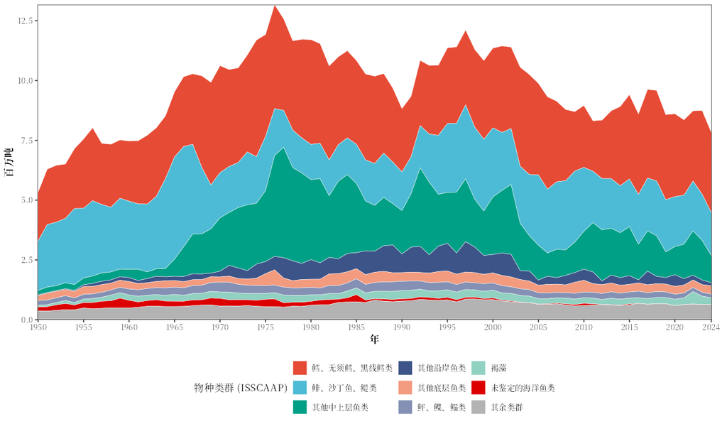

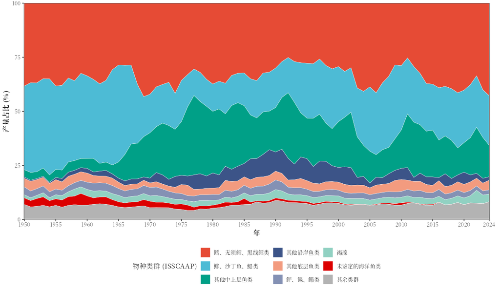

第一幅图显示各类群的产量，第二幅图显示各类群在每年总产量中的占比。产量最大的`top_n`个类群单独显示，其余合并为一类。表格列出各类群每个年代的年均产量、最近五年每年的产量，以及最后一年的占比（吨和%）：

```r
show_table(groups$table, digits = 0)
```

| 物种类群 (ISSCAAP) | 1950s | 1960s | 1970s | 1980s | 1990s | 2000s | 2010s | 2020s | 2020 | 2021 | 2022 | 2023 | 2024 | share_2024_pct |
| --- | --- | --- | --- | --- | --- | --- | --- | --- | --- | --- | --- | --- | --- | --- |
| 鳕、无须鳕、黑线鳕类 | 2,507,170 | 3,022,010 | 4,169,322 | 3,694,448 | 2,971,859 | 3,518,007 | 3,122,258 | 3,280,509 | 3,463,440 | 3,149,488 | 2,932,054 | 3,502,551 | 3,355,012 | 43 |
| 鲱、沙丁鱼、鳀类 | 2,779,324 | 3,202,760 | 1,865,383 | 1,621,417 | 2,425,069 | 2,688,692 | 2,175,941 | 1,988,596 | 2,089,755 | 2,049,083 | 2,079,641 | 1,928,844 | 1,795,658 | 23 |
| 其他中上层鱼类 | 269,410 | 890,080 | 3,173,777 | 2,661,330 | 2,371,030 | 1,735,251 | 1,761,012 | 1,454,800 | 1,176,739 | 1,441,312 | 1,857,547 | 1,654,906 | 1,143,495 | 15 |
| 其他沿岸鱼类 | 77,690 | 186,400 | 546,076 | 833,692 | 989,272 | 505,487 | 337,299 | 252,807 | 483,374 | 266,377 | 197,125 | 193,064 | 124,098 | 2 |
| 其他底层鱼类 | 285,220 | 263,060 | 345,996 | 424,319 | 405,580 | 382,355 | 358,843 | 328,769 | 329,019 | 333,933 | 315,636 | 314,796 | 350,461 | 4 |
| 鲆、鲽、鳎类 | 203,200 | 306,580 | 346,399 | 351,725 | 340,789 | 260,697 | 250,601 | 182,052 | 213,784 | 203,179 | 172,402 | 166,824 | 154,073 | 2 |
| 褐藻 | 141,882 | 249,340 | 282,269 | 279,593 | 316,267 | 262,672 | 242,414 | 335,848 | 263,397 | 272,022 | 518,245 | 349,189 | 276,387 | 4 |
| 未鉴定的海洋鱼类 | 252,710 | 246,840 | 248,921 | 153,214 | 87,960 | 33,651 | 24,212 | 4,129 | 4,912 | 8,694 | 4,501 | 2,200 | 340 | 0 |
| 其余类群 | 439,560 | 563,979 | 564,321 | 716,972 | 822,271 | 696,854 | 635,533 | 631,309 | 587,282 | 634,639 | 654,495 | 637,457 | 642,670 | 8 |

```r
species_group_composition(FAO27$area_data, group = "major", lang = "zh")
```

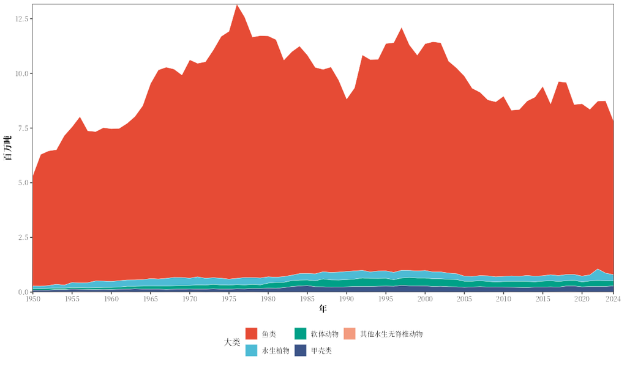

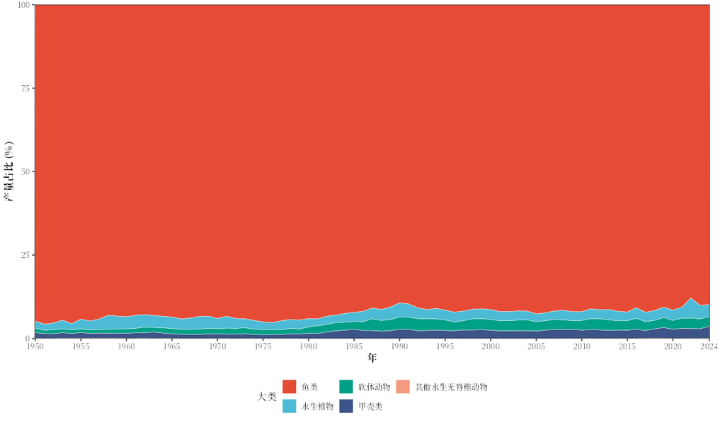

| 参数 | 含义 | 默认值 |
| --- | --- | --- |
| `group` | `"isscaap"`（ISSCAAP物种类群）或`"major"`（大类） | `"isscaap"` |
| `top_n` | 单独显示的类群数，其余合并 | `8` |
| `area_data`、`plot`、`table`、`lang`、`pptx`、`label` | 见通用参数 |  |

输出：图`<label>_group_isscaap.png`（或`_group_major`）和`..._share.png`，表格`<label>_group_isscaap.csv`；函数返回`yearly`（各类群逐年产量）和`table`。

## 🚦 资源状态图

`stock_status()`根据每个物种的产量相对于其序列**峰值产量**的比例，逐年判定该产量序列的资源开发状态（Kleisner et al. 2013）：

| 状态 | 判定规则 |
| --- | --- |
| 开发中(Developing) | 峰值年之前，产量不超过峰值的50% |
| 充分开发(Exploited) | 产量高于峰值的50% |
| 过度开发(Over-exploited) | 峰值年之后，产量在峰值的10%至50%之间 |
| 崩溃(Collapsed) | 峰值年之后，产量低于峰值的10% |
| 恢复中(Rebuilding) | 崩溃之后，产量回升至峰值的10%至50%之间 |

```r
status <- stock_status(FAO27$area_data)
```

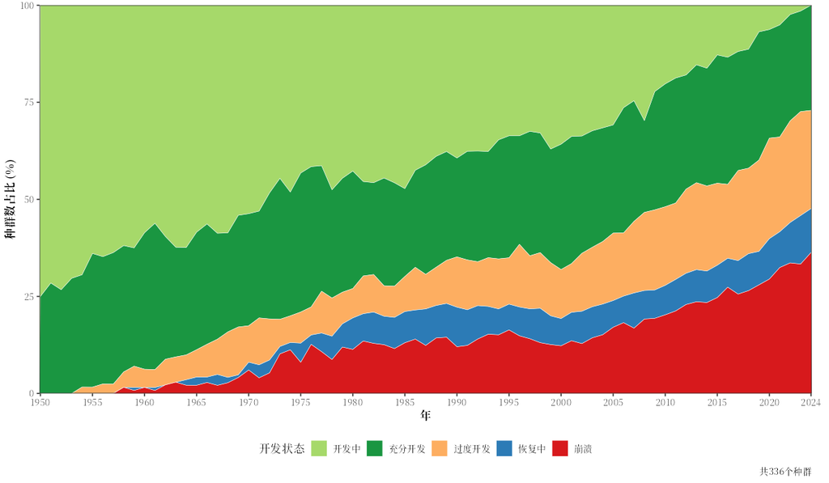

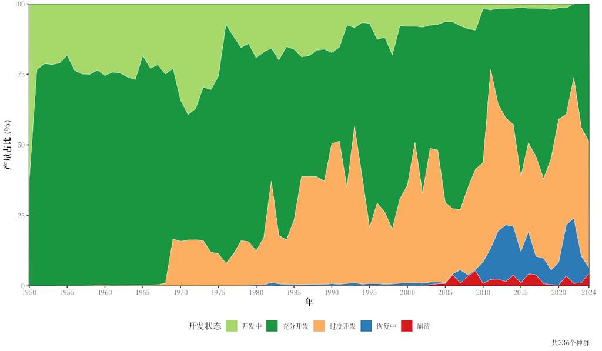

第一幅图是处于各状态的**种群**数量占比，第二幅图是各状态的**产量**占比。这里的“种群”指数据中的一个物种条目（所有国家合计），最后一次报告产量之后的年份按零产量计。只有符合纳入标准的序列才会参与分类：

| 参数 | 含义 | 默认值 |
| --- | --- | --- |
| `taxon_levels` | 纳入的分类阶元：`"species"`、`"genus"`、`"family"`和`"higher"`中的任意几个（“Marine fishes nei”等合并类群属于`"higher"`） | `c("species", "genus", "family")` |
| `min_years` | 从首次到最后一次有产量的最少年数 | `10` |
| `min_consecutive` | 连续有产量的最少年数 | `5` |
| `min_catch` | 序列的最低总产量（吨） | `1000` |
| `smooth` | 分类前是否先做3年滑动平均 | `FALSE` |
| `area_data`、`plot`、`table`、`lang`、`pptx`、`label` | 见通用参数 |  |

种群表列出每个种群的峰值年份及其最后一年的状态：

```r
show_table(status$stocks, digits = 0)
```

| species_name | species_en | first_year | peak_year | peak_tonnes | last_year_tonnes | pct_of_peak | status_last_year |
| --- | --- | --- | --- | --- | --- | --- | --- |
| 毛鳞鱼 | Capelin | 1950 | 1977 | 3,773,808 | 168693.267 | 4 | 崩溃 |
| 大西洋鲱 | Atlantic herring | 1950 | 1965 | 3,736,100 | 1250851.116 | 33 | 过度开发 |
| 小鳍鳕 | Blue whiting(=Poutassou) | 1950 | 2004 | 2,419,291 | 1832649.131 | 76 | 充分开发 |
| 大西洋鳕 | Atlantic cod | 1950 | 1969 | 2,147,600 | 762408.034 | 36 | 过度开发 |
| 大西洋鲭 | Atlantic mackerel | 1950 | 2014 | 1,382,490 | 904016.963 | 65 | 充分开发 |
| Sandeels(=Sandlances) nei | Sandeels(=Sandlances) nei | 1954 | 1997 | 1,242,671 | 96630.953 | 8 | 崩溃 |
| 黍鲱 | European sprat | 1950 | 1975 | 982,776 | 343221.482 | 35 | 过度开发 |
| 黑线鳕 | Haddock | 1950 | 1969 | 889,200 | 293250.936 | 33 | 过度开发 |
| 挪威长臀鳕 | Norway pout | 1959 | 1974 | 877,910 | 5372.615 | 1 | 崩溃 |
| 青鳕 Saithe(=Pollock) | Saithe(=Pollock) | 1950 | 1974 | 723,652 | 299652.086 | 41 | 过度开发 |

```r
table(status$stocks$status_last_year)
```

```
#>
#> 充分开发     崩溃   恢复中 过度开发
#>       91      122       38       85
```

```r
# 平滑后的产量，更严格的纳入标准
stock_status(FAO27$area_data, smooth = TRUE, min_catch = 10000, label = "FAO27 smoothed")
```

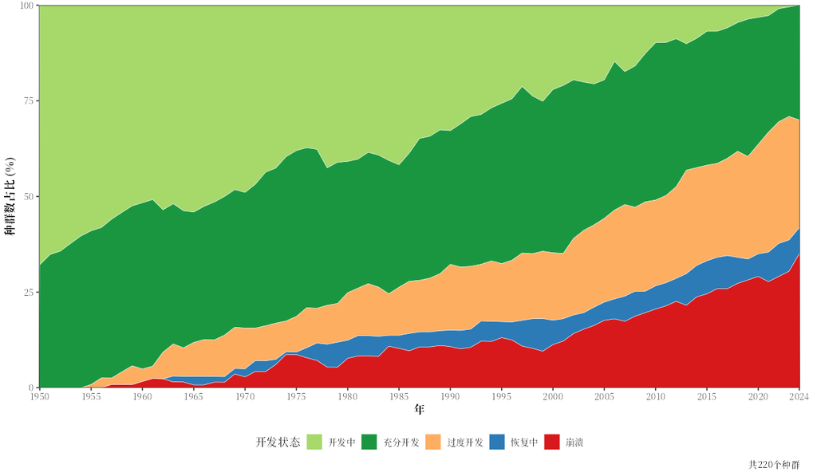

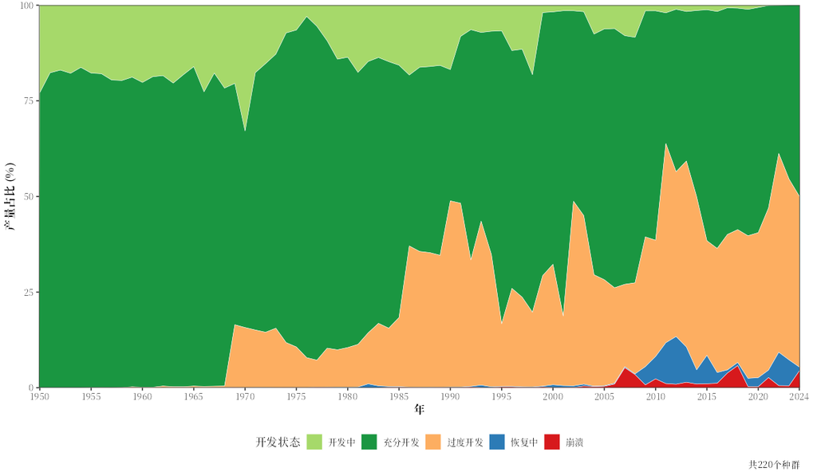

输出：图`<label>_stock_status_stocks.png`和`<label>_stock_status_catch.png`，表格`<label>_stock_status.csv`（各状态逐年的种群数和产量）和`<label>_stock_status_stocks.csv`；函数返回`yearly`、`stocks`和`status`（每个种群每年的状态）。

资源状态图只使用产量数据。产量下降也可能源于管理措施、市场或数据上报的变化，因此结果仅供参考，不能替代资源评估。

## ⛰️ 峰值与趋势

`peak_trend()`针对总产量以及主要物种（或国家、渔区），找出**峰值产量**出现的年份和数值、最后一年产量相当于**峰值的百分比**，以及最近`recent_years`年的趋势：

- **年均增长率**（`growth_pct_per_year`）：这段时间首年到末年之间的年均增长率，即$100\,[(C_n/C_1)^{1/(n-1)} - 1]$，其中$C_1$和$C_n$分别是这$n$年中第一年和最后一年的产量；
- **趋势**：Mann-Kendall趋势检验（Mann 1945；Kendall 1975），即年份与产量之间的Kendall τ。渔获序列有自相关，普通检验会找出过多的趋势，因此检验的方差按AR(1)过程的有效样本量校正（Yue and Wang 2004），所用的一阶自相关取自去趋势后的序列，并校正了小样本偏差（Kendall 1954；`lag1_autocorrelation`）。`p_value`是校正后的p值，`p_value_iid`是普通检验的p值。`p_value` < 0.05时`trend`为`"up"`（上升）或`"down"`（下降），否则为`"none"`。只有十年数据时，校正只能部分起作用：自相关很强的序列仍会过多地显示趋势。
- **多条序列**：在十条或更多序列中，总有一些序列偶然显示出趋势。`q_value`按结果中的序列数（不含总产量）校正p值（Benjamini and Hochberg 1995）。`p_value` < 0.05的趋势应视为探索性的结果，`q_value` < 0.05的才作为显著趋势；📝 评估报告对主要种类和主要国家就是这样处理的。

```r
species_trend <- peak_trend(FAO27$area_data, by = "species", top_n = 10)
```

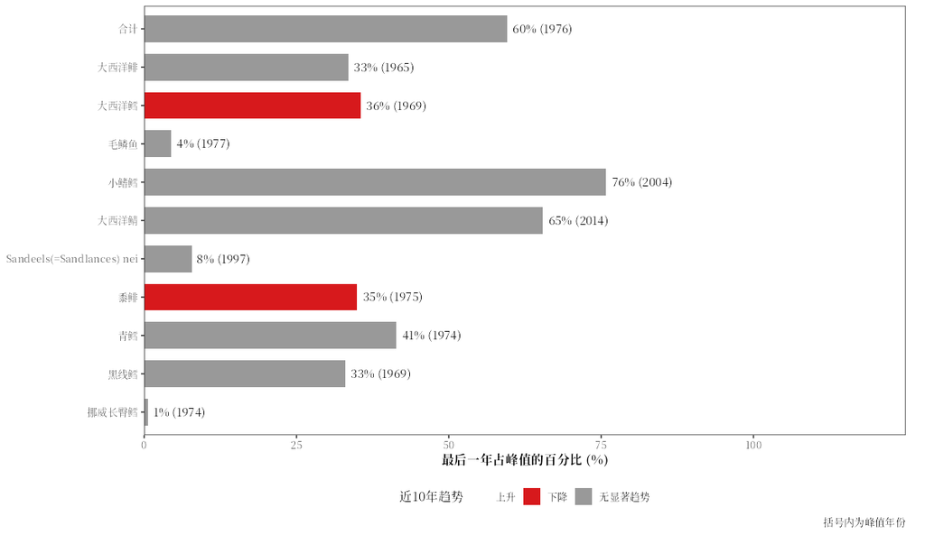

```r
show_table(species_trend[, c("name", "peak_year", "pct_of_peak", "growth_pct_per_year", "kendall_tau", "p_value", "q_value", "trend")])
```

|  | name | peak_year | pct_of_peak | growth_pct_per_year | kendall_tau | p_value | q_value | trend |
| --- | --- | --- | --- | --- | --- | --- | --- | --- |
| p | 合计 | 1976 | 59.53 | -2.0050033 | -0.33 | 0.21 | NA | none |
| p1 | 大西洋鲱 | 1965 | 33.48 | -0.4745389 | -0.20 | 0.71 | 0.95 | none |
| p2 | 大西洋鳕 | 1969 | 35.50 | -5.2914437 | -0.82 | 0.03 | 0.16 | down |
| p3 | 毛鳞鱼 | 1977 | 4.47 | -13.1229391 | -0.02 | 1.00 | 1.00 | none |
| p4 | 小鳍鳕 | 2004 | 75.75 | 2.9400918 | 0.16 | 0.74 | 0.95 | none |
| p5 | 大西洋鲭 | 2014 | 65.39 | -3.1263873 | -0.38 | 0.33 | 0.83 | none |
| p6 | Sandeels(=Sandlances) nei | 1997 | 7.78 | -12.5836285 | -0.47 | 0.07 | 0.25 | none |
| p7 | 黍鲱 | 1975 | 34.92 | -5.7343149 | -0.82 | 0.00 | 0.01 | down |
| p8 | 青鳕 | 1974 | 41.41 | 0.4885031 | 0.11 | 0.84 | 0.95 | none |
| p9 | 黑线鳕 | 1969 | 32.98 | 0.3336638 | 0.07 | 0.86 | 0.95 | none |

```r
peak_trend(FAO27$area_data, by = "country", top_n = 15, recent_years = 20, lang = "zh")
```

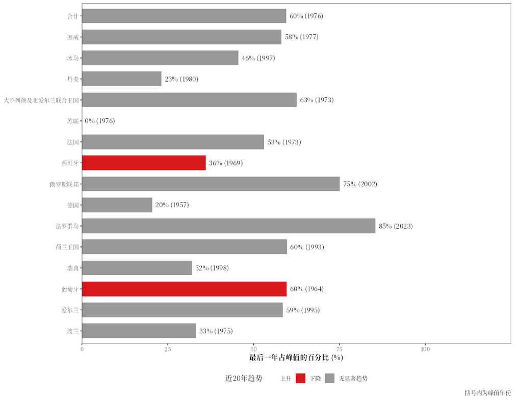

| 参数 | 含义 | 默认值 |
| --- | --- | --- |
| `by` | 比较的对象：`"species"`、`"country"`或`"area"` | `"species"` |
| `top_n` | 取总产量最大的几个序列（`Inf`表示全部） | `10` |
| `recent_years` | 计算趋势所用的最近年数 | `10` |
| `area_data`、`plot`、`table`、`lang`、`pptx`、`label` | 见通用参数 |  |

输出：图`<label>_peak_trend_species.png`（或`_country`、`_area`）和同名表格；函数返回一个数据框，每个序列一行，第一行是总产量。

## 🌍 全部FAO海洋渔区

`area_overview()`对比全部FAO海洋渔区：给出各渔区产量随时间的变化并标出峰值，以及各渔区的峰值与趋势图（即`peak_trend(by = "area")`）：

```r
overview <- area_overview()
```

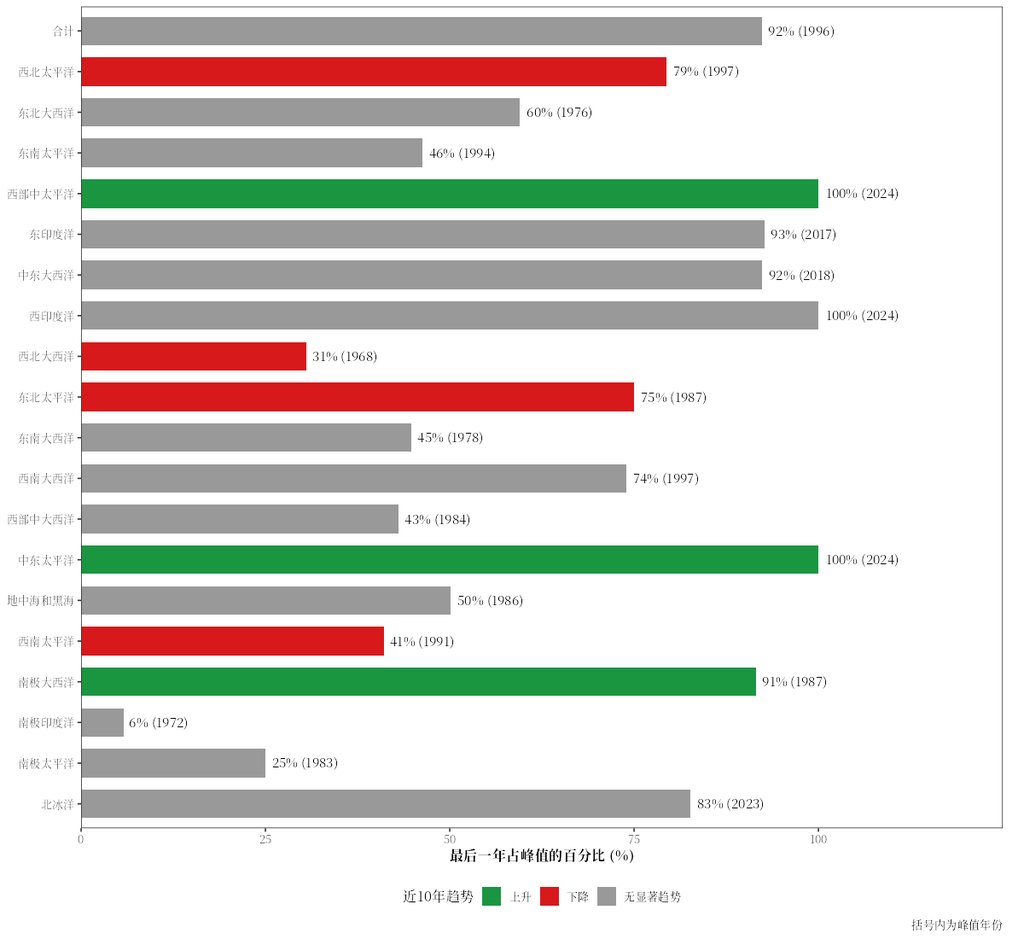

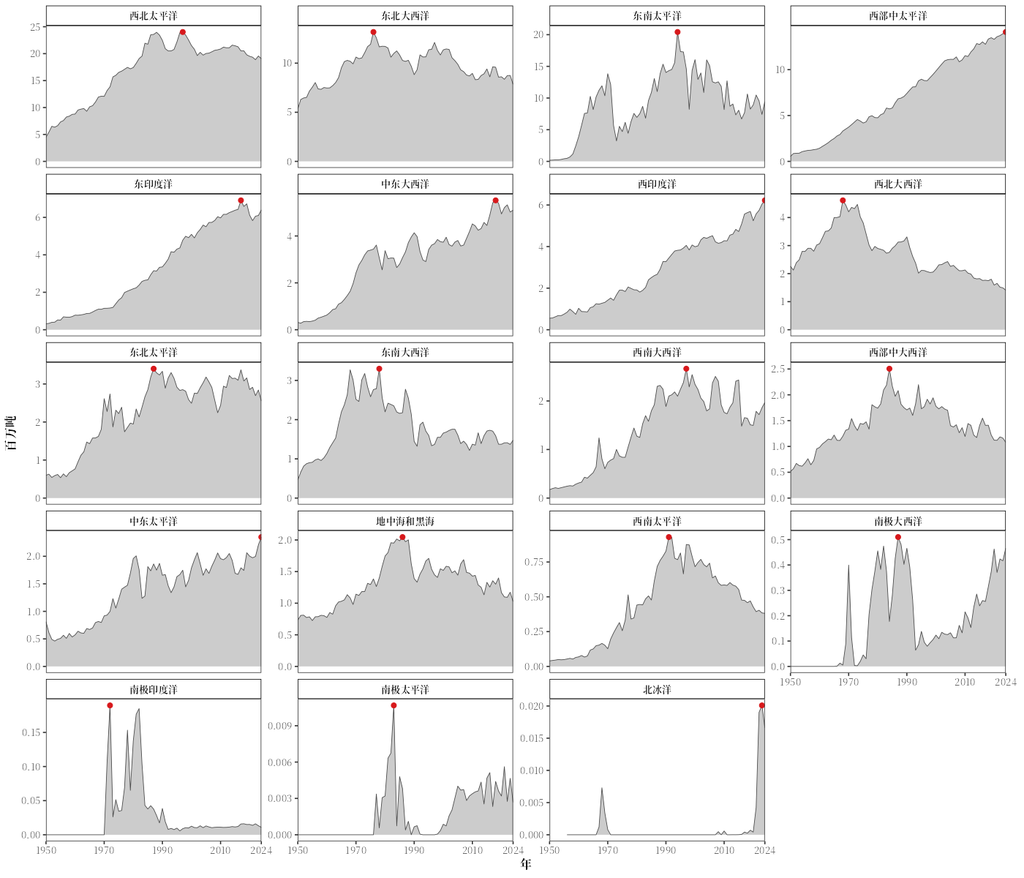

```r
show_table(overview[, c("name", "peak_year", "peak_tonnes", "last_year_tonnes", "pct_of_peak", "trend")], n = 20, digits = 0)
```

|  | name | peak_year | peak_tonnes | last_year_tonnes | pct_of_peak | trend |
| --- | --- | --- | --- | --- | --- | --- |
| p | 合计 | 1996 | 87,687,040 | 80930379.329 | 92 | none |
| p1 | 西北太平洋 | 1997 | 24,020,927 | 19067991.408 | 79 | down |
| p2 | 东北大西洋 | 1976 | 13,172,602 | 7842194.162 | 60 | none |
| p3 | 东南太平洋 | 1994 | 20,422,424 | 9453525.210 | 46 | none |
| p4 | 西部中太平洋 | 2024 | 14,105,189 | 14105189.055 | 100 | up |
| p5 | 东印度洋 | 2017 | 6,910,165 | 6401679.921 | 93 | none |
| p6 | 中东大西洋 | 2018 | 5,520,055 | 5099475.194 | 92 | none |
| p7 | 西印度洋 | 2024 | 6,223,934 | 6223934.387 | 100 | none |
| p8 | 西北大西洋 | 1968 | 4,612,569 | 1407262.000 | 31 | down |
| p9 | 东北太平洋 | 1987 | 3,401,535 | 2551440.501 | 75 | down |
| p10 | 东南大西洋 | 1978 | 3,299,221 | 1475796.444 | 45 | none |
| p11 | 西南大西洋 | 1997 | 2,664,636 | 1970436.942 | 74 | none |
| p12 | 西部中大西洋 | 1984 | 2,505,870 | 1077647.351 | 43 | none |
| p13 | 中东太平洋 | 2024 | 2,349,505 | 2349505.260 | 100 | up |
| p14 | 地中海和黑海 | 1986 | 2,046,352 | 1026111.034 | 50 | none |
| p15 | 西南太平洋 | 1991 | 929,232 | 381352.879 | 41 | down |
| p16 | 南极大西洋 | 1987 | 510,151 | 466706.916 | 91 | up |
| p17 | 南极印度洋 | 1972 | 189,586 | 10861.059 | 6 | none |
| p18 | 南极太平洋 | 1983 | 10,678 | 2665.606 | 25 | none |
| p19 | 北冰洋 | 2023 | 20,094 | 16604.000 | 83 | none |

| 参数 | 含义 | 默认值 |
| --- | --- | --- |
| `recent_years` | 计算趋势所用的最近年数 | `10` |
| `data_version` | 使用的FAO数据版本（见`load_fao_data()`） | `"latest"` |
| `plot`、`table`、`lang`、`pptx` | 见通用参数 |  |

`area_overview()`自己读取FAO数据，所以没有`area_data`和`label`参数。输出：图`marine_areas_catch.png`、`marine_areas_peak_trend_area.png`和表格`marine_areas_peak_trend_area.csv`；函数返回`peak_trend()`的数据框。

## 🔀 突变点同步性

`regime_shift()`对主要物种（所有物种条目，包括nei类群）的产量序列做突变点分析，并统计每一年有多少个物种的平均产量发生变化。每个序列在平均值发生变化处分段（`strucchange::breakpoints()`，Bai and Perron 2003；Zeileis et al. 2002，2003），突变点个数按BIC选择；突变点的年份是新时段的第一年。许多物种在同一年发生变化，可能意味着整个生态系统发生了生态系统转变(regime shift)，也可能源于管理或数据上报方式的改变。

```r
shifts <- regime_shift(FAO27$area_data, top_n = 20)
```

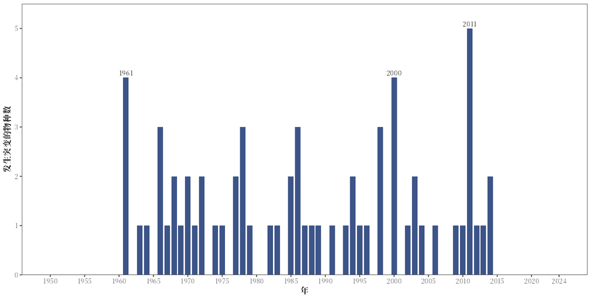

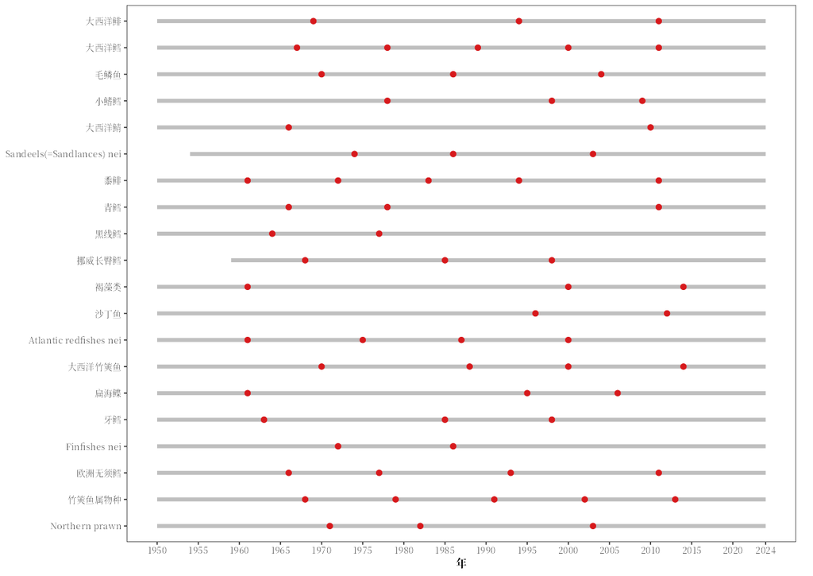

```r
show_table(shifts$breakpoints[, c("species", "first_year", "n_breakpoints", "breakpoint_years")], n = 20)
```

| species | first_year | n_breakpoints | breakpoint_years |
| --- | --- | --- | --- |
| 大西洋鲱 | 1950 | 3 | 1969, 1994, 2011 |
| 大西洋鳕 | 1950 | 5 | 1967, 1978, 1989, 2000, 2011 |
| 毛鳞鱼 | 1950 | 3 | 1970, 1986, 2004 |
| 小鳍鳕 | 1950 | 3 | 1978, 1998, 2009 |
| 大西洋鲭 | 1950 | 2 | 1966, 2010 |
| Sandeels(=Sandlances) nei | 1954 | 3 | 1974, 1986, 2003 |
| 黍鲱 | 1950 | 5 | 1961, 1972, 1983, 1994, 2011 |
| 青鳕 | 1950 | 3 | 1966, 1978, 2011 |
| 黑线鳕 | 1950 | 2 | 1964, 1977 |
| 挪威长臀鳕 | 1959 | 3 | 1968, 1985, 1998 |
| 褐藻类 | 1950 | 3 | 1961, 2000, 2014 |
| 沙丁鱼 | 1950 | 2 | 1996, 2012 |
| Atlantic redfishes nei | 1950 | 4 | 1961, 1975, 1987, 2000 |
| 大西洋竹筴鱼 | 1950 | 4 | 1970, 1988, 2000, 2014 |
| 扁海鲽 | 1950 | 3 | 1961, 1995, 2006 |
| 牙鳕 | 1950 | 3 | 1963, 1985, 1998 |
| Finfishes nei | 1950 | 2 | 1972, 1986 |
| 欧洲无须鳕 | 1950 | 4 | 1966, 1977, 1993, 2011 |
| 竹筴鱼属物种 | 1950 | 5 | 1968, 1979, 1991, 2002, 2013 |
| Northern prawn | 1950 | 3 | 1971, 1982, 2003 |

```r
head(shifts$yearly[order(-shifts$yearly$n_species), ], 5)
```

```
#>    Year n_species
#> 62 2011         5
#> 12 1961         4
#> 51 2000         4
#> 17 1966         3
#> 29 1978         3
```

| 参数 | 含义 | 默认值 |
| --- | --- | --- |
| `top_n` | 分析总产量最大的几个物种 | `20` |
| `h_value` | 两个突变点之间的最短时段：序列长度的比例或年数 | `0.15` |
| `area_data`、`plot`、`table`、`lang`、`pptx`、`label` | 见通用参数 |  |

序列太短、不满足`h_value`的物种会跳过并给出提示。输出：图`<label>_regime_shift.png`（每年发生突变的物种数）和`<label>_regime_shift_species.png`（各物种的突变点），表格`<label>_regime_shift.csv`和`<label>_regime_shift_years.csv`；函数返回`breakpoints`和`yearly`。

## 🐟 中上层鱼/底层鱼渔获比

`pelagic_demersal()`计算每个FAO海洋渔区中上层鱼渔获量与底层鱼渔获量之比（P/D），按年和按年代给出。Caddy (1993)提出，营养盐增加有利于以浮游生物为食、寿命短的中上层鱼，而不利于底层鱼；de Leiva Moreno et al. (2000)用P/D作为欧洲周边海域营养水平的替代指标。每个年代的P/D是该年代各年P/D的平均值（与Hondorp et al. 2010相同），并给出最低值和最高值。

```r
pd <- pelagic_demersal(FAO27$area_data)
```

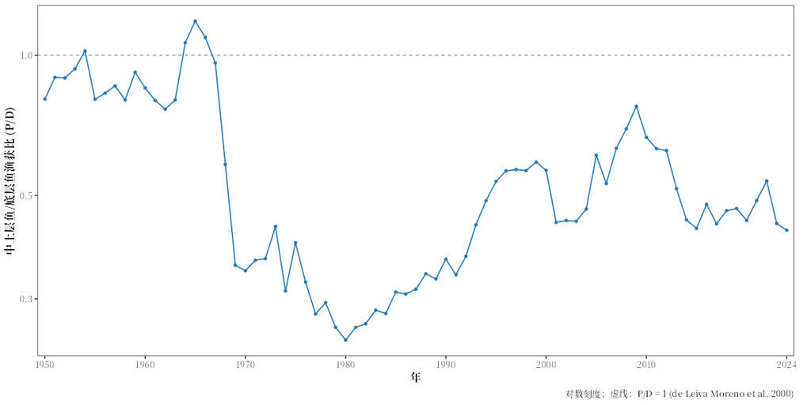

```r
show_table(pd$decades[, c("period", "pd_mean", "pd_min", "pd_max", "counted_pct")])
```

| period | pd_mean | pd_min | pd_max | counted_pct |
| --- | --- | --- | --- | --- |
| 1950s | 0.88 | 0.80 | 1.02 | 85.66 |
| 1960s | 0.85 | 0.35 | 1.18 | 79.60 |
| 1970s | 0.34 | 0.26 | 0.43 | 64.27 |
| 1980s | 0.29 | 0.24 | 0.34 | 66.68 |
| 1990s | 0.48 | 0.34 | 0.59 | 68.98 |
| 2000s | 0.56 | 0.44 | 0.78 | 75.38 |
| 2010s | 0.52 | 0.43 | 0.67 | 72.70 |
| 2020s | 0.46 | 0.42 | 0.54 | 74.33 |

```r
show_table(pd$groups[, c("group", "counted_as", "catch_pct")], n = 12)
```

| group | counted_as | catch_pct |
| --- | --- | --- |
| 鳕、无须鳕、黑线鳕类 | demersal | 34.17 |
| 鲱、沙丁鱼、鳀类 | pelagic | 24.62 |
| 其他中上层鱼类 | not counted | 18.84 |
| 其他沿岸鱼类 | demersal | 5.00 |
| 其他底层鱼类 | demersal | 3.65 |
| 鲆、鲽、鳎类 | demersal | 2.98 |
| 褐藻 | not counted | 2.69 |
| 未鉴定的海洋鱼类 | not counted | 1.46 |
| 虾类 | demersal | 1.11 |
| 鲨、鳐、银鲛类 | not counted | 0.87 |
| 贻贝类 | not counted | 0.63 |
| 蛤、鸟蛤、蚶类 | not counted | 0.54 |

FAO数据中每个物种都有一个ISSCAAP类群，所以函数按类群划分。`fao_pd_groups()`（没有参数）列出两种已发表的定义如何计算每个类群：

| `definition` | 中上层鱼 | 底层鱼 |
| --- | --- | --- |
| `"de_leiva_moreno"`（默认） | 鲱、沙丁鱼、鳀类（小型中上层鱼） | 鲆鲽类、鳕类、其他沿岸鱼类、其他底层鱼类、海洋甲壳类（磷虾除外） |
| `"grainger_garcia"`（Grainger and Garcia 1996） | 小型中上层鱼、金枪鱼和旗鱼类、其他中上层鱼类 | 鲆鲽类、鳕类、其他沿岸鱼类、其他底层鱼类、鲨鳐类、未鉴定的海洋鱼类 |

```r
show_table(fao_pd_groups(), n = 15)
```

| isscaap_code | isscaap_en | de_leiva_moreno | grainger_garcia |
| --- | --- | --- | --- |
| 31 | Flounders, halibuts, soles | demersal | demersal |
| 32 | Cods, hakes, haddocks | demersal | demersal |
| 33 | Miscellaneous coastal fishes | demersal | demersal |
| 34 | Miscellaneous demersal fishes | demersal | demersal |
| 35 | Herrings, sardines, anchovies | pelagic | pelagic |
| 36 | Tunas, bonitos, billfishes | not counted | pelagic |
| 37 | Miscellaneous pelagic fishes | not counted | pelagic |
| 38 | Sharks, rays, chimaeras | not counted | demersal |
| 39 | Marine fishes not identified | not counted | demersal |
| 42 | Crabs, sea-spiders | demersal | not counted |
| 43 | Lobsters, spiny-rock lobsters | demersal | not counted |
| 44 | King crabs, squat-lobsters | demersal | not counted |
| 45 | Shrimps, prawns | demersal | not counted |
| 46 | Krill, planktonic crustaceans | not counted | not counted |
| 47 | Miscellaneous marine crustaceans | demersal | not counted |

| 参数 | 含义 | 默认值 |
| --- | --- | --- |
| `definition` | 哪些类群算中上层鱼和底层鱼：`"de_leiva_moreno"`或`"grainger_garcia"` | `"de_leiva_moreno"` |
| `pelagic`、`demersal` | 改用自己指定的ISSCAAP类群（使用FAO数据中的英文名，如`"Herrings, sardines, anchovies"`），代替`definition`的类群 | `NULL` |
| `by` | `"area"`，或`"division"`（用于`load_fao_divisions()`的分区渔获数据，🧩扩展功能） | `"area"` |
| `area_data`、`plot`、`table`、`lang`、`pptx`、`label` | 见通用参数 |  |

内陆渔区会被剔除，并给出提示。输出：图`<label>_pelagic_demersal_ratio.png`（逐年P/D，每个渔区一个分图）、`<label>_pelagic_demersal.png`和`..._share.png`（中上层鱼、底层鱼和其他渔获），表格`<label>_pelagic_demersal.csv`、`..._decades.csv`和`..._groups.csv`；函数返回`yearly`、`decades`和`groups`。

### 🧩 按分区计算（扩展功能）

de Leiva Moreno et al. (2000)比较的是地中海和黑海的各个分区。区域渔业组织的分区渔获数据中有同样的分区，用`load_fao_divisions()`读取（这是本包的扩展功能，不纳入Word报告；其他数据集见🚢 贸易与就业）：

```r
pelagic_demersal(load_fao_divisions("GFCM"), by = "division")
```

在2026.1.0版数据中，1980年代的平均P/D在爱奥尼亚海（0.6）和黎凡特海（0.4）低于1，在亚得里亚海约为4，在黑海约为18，分别落在de Leiva Moreno et al. (2000)给出的贫营养、中营养和富营养海域的范围内。

## 📝 写入Word报告

`fao_report()`可以把这些分析写进某个渔区的Word报告（见📝 一键生成评估报告（Word、LaTeX、PDF））。ISSCAAP类群（`groups = TRUE`）和资源状态图（`status = TRUE`）默认就是报告的章节；中上层鱼/底层鱼渔获比用`pelagic = TRUE`加入。各函数的设置以章节名为前缀传入，例如`status_smooth = TRUE`就是`stock_status()`的`smooth = TRUE`：

```r
fao_report(27, pelagic = TRUE, status_smooth = TRUE, pelagic_definition = "grainger_garcia")
```

报告中主要物种表和主要国家表的趋势由`peak_trend()`计算；`area_overview()`和`regime_shift()`不在报告中。

## 📖 参考文献

Bai, J. and Perron, P. (2003). Computation and analysis of multiple structural change models. *Journal of Applied Econometrics* 18: 1–22. [doi:10.1002/jae.659](https://doi.org/10.1002/jae.659)

Benjamini, Y. and Hochberg, Y. (1995). Controlling the false discovery rate: a practical and powerful approach to multiple testing. *Journal of the Royal Statistical Society: Series B* 57: 289–300. [doi:10.1111/j.2517-6161.1995.tb02031.x](https://doi.org/10.1111/j.2517-6161.1995.tb02031.x)

Caddy, J.F. (1993). Toward a comparative evaluation of human impacts on fishery ecosystems of enclosed and semi-enclosed seas. *Reviews in Fisheries Science* 1: 57–95. [doi:10.1080/10641269309388535](https://doi.org/10.1080/10641269309388535)

Caddy, J.F., Carocci, F. and Coppola, S. (1998). Have peak fishery production levels been passed in continental shelf area? Some perspectives arising from historical trends in production per shelf area. *Journal of Northwest Atlantic Fishery Science* 23: 191–219. [doi:10.2960/J.v23.a13](https://doi.org/10.2960/J.v23.a13)

de Leiva Moreno, J.I., Agostini, V.N., Caddy, J.F. and Carocci, F. (2000). Is the pelagic-demersal ratio from fishery landings a useful proxy for nutrient availability? A preliminary data exploration for the semi-enclosed seas around Europe. *ICES Journal of Marine Science* 57: 1091–1102. [doi:10.1006/jmsc.2000.0705](https://doi.org/10.1006/jmsc.2000.0705)

FAO (2026). *Global Capture Production 1950–2024*, release 2026.1.0. In: Fisheries and Aquaculture. Rome: FAO. https://www.fao.org/fishery/collection/capture/en. Licence: CC BY 4.0. Release file: https://www.fao.org/fishery/static/Data/Capture_2026.1.0.zip

Grainger, R.J.R. and Garcia, S.M. (1996). *Chronicles of marine fishery landings (1950–1994): trend analysis and fisheries potential*. FAO Fisheries Technical Paper 359. Rome: FAO. https://www.fao.org/4/w3244e/w3244e00.htm

Hondorp, D.W., Breitburg, D.L. and Davias, L.A. (2010). Eutrophication and fisheries: separating the effects of nitrogen loads and hypoxia on the pelagic-to-demersal ratio and other measures of landings composition. *Marine and Coastal Fisheries* 2: 339–361. [doi:10.1577/C09-020.1](https://doi.org/10.1577/C09-020.1)

Kendall, M.G. (1954). Note on bias in the estimation of autocorrelation. *Biometrika* 41: 403–404. [doi:10.1093/biomet/41.3-4.403](https://doi.org/10.1093/biomet/41.3-4.403)

Kendall, M.G. (1975). *Rank correlation methods*, 4th edition. London: Charles Griffin.

Kleisner, K., Zeller, D., Froese, R. and Pauly, D. (2013). Using global catch data for inferences on the world’s marine fisheries. *Fish and Fisheries* 14: 293–311. [doi:10.1111/j.1467-2979.2012.00469.x](https://doi.org/10.1111/j.1467-2979.2012.00469.x)

Mann, H.B. (1945). Nonparametric tests against trend. *Econometrica* 13: 245–259. [doi:10.2307/1907187](https://doi.org/10.2307/1907187)

Yue, S. and Wang, C.Y. (2004). The Mann-Kendall test modified by effective sample size to detect trend in serially correlated hydrological series. *Water Resources Management* 18: 201–218. [doi:10.1023/B:WARM.0000043140.61082.60](https://doi.org/10.1023/B:WARM.0000043140.61082.60)

Zeileis, A., Leisch, F., Hornik, K. and Kleiber, C. (2002). strucchange: an R package for testing for structural change in linear regression models. *Journal of Statistical Software* 7(2): 1–38. [doi:10.18637/jss.v007.i02](https://doi.org/10.18637/jss.v007.i02)

Zeileis, A., Kleiber, C., Krämer, W. and Hornik, K. (2003). Testing and dating of structural changes in practice. *Computational Statistics & Data Analysis* 44: 109–123. doi:10.1016/S0167-9473(03)00030-6